# Prédire la résistance aux antibiotiques chez *Escherichia coli*

Du choix de la molécule à l’interprétation — de la ciprofloxacine aux 48 antibiotiques

Benjamin HIN

2026

## Plan

### Quatre temps

1. **Les données** — 48 antibiotiques, un seul génome, un problème de choix.
2. **De 48 à 1** — couverture, prévalence, critères d’éligibilité.
3. **Exploration détaillée** — ciprofloxacine : modèles, seuil, SHAP, deep learning.
4. **Passage à l’échelle** — 8 antibiotiques, et ce que le classement raconte.

> Une seule question : à quelles conditions un modèle de résistance est-il **utile** ?

## Contexte

### Un problème de santé publique

- La résistance aux antimicrobiens est associée à **≈ 5 millions de décès par an**, dont **1,3 million** directement attribuables (2019).
- *Escherichia coli* : pathogène majeur, porteur de nombreux mécanismes de résistance.
- L’**antibiogramme** demande 24 à 72 h ; le **séquençage** du génome prend quelques heures.

### L’idée

> Prédire le phénotype **sensible / résistant** à partir du génotype, assez tôt pour orienter le traitement.

### Mais…

- Tous les antibiotiques ne se valent pas : ni par le nombre de cas, ni par la biologie de leur résistance.
- Un bon score sur un antibiotique facile ne dit rien sur les autres.

## Les données

### Un jeu *E. coli* × 48 antibiotiques

| Élément | Valeur |
| --- | --- |
| Génomes | **6 949** |
| Features binaires (pangénome + variants) | **34 744** |
| Antibiotiques | **48** |
| Splits train / val / test | **4 722 / 1 110 / 1 117** |

### La cible

- `1` = résistant, `0` = sensible, `NA` = non testé.
- Chaque antibiotique n’est observé que sur une **partie** des génomes.
- Conséquence : chaque ATB a ses propres effectifs et sa propre prévalence.

## Splits : éviter la fuite de lignage

### Le piège

- Un split aléatoire place des **clones proches** dans le train et le test.
- Le modèle apprend des **marqueurs de lignée** plutôt que la résistance.

### Le protocole

- `StratifiedGroupKFold` à **6 folds**, groupes = **lignée** (MLST).
- 4 folds train / 1 validation / 1 test.
- Aucune lignée connue dans deux splits ; lignées inconnues = groupes individuels.
- Stratification sur la **charge de résistance** (multi-label), pas sur un seul ATB.

### Ce que cela change

- Estimation **honnête** de la généralisation à des lignées non vues.
- Mais effectifs par ATB plus petits → métriques adaptées au déséquilibre.

## Le vrai problème : 48 antibiotiques, mais combien d’exploitables ?

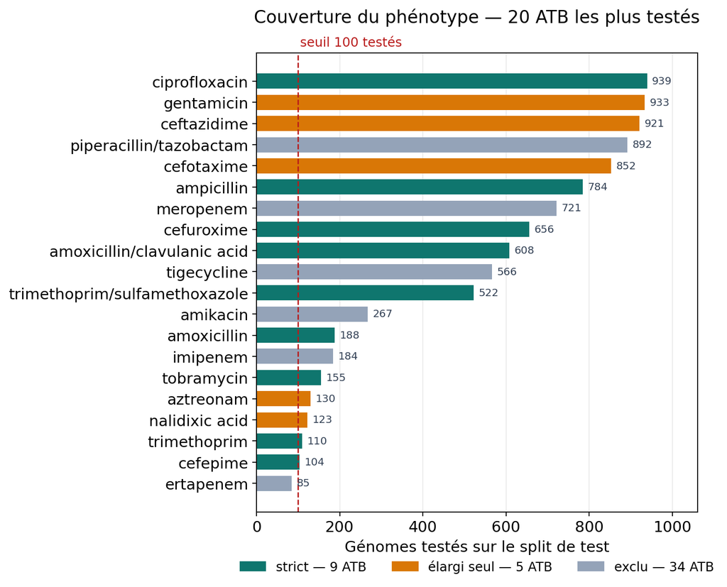

### Deux filtres

1. **Couverture** : au moins **100 génomes testés** sur *chaque* split.
2. **Prévalence** : classe minoritaire **≥ 10 %** (strict) ou **≥ 5 %** (élargi).

### Résultat

- **9 ATB stricts**
- **14 ATB élargis**
- **34 ATB exclus**

Seuls **14 ATB sur 48** sont exploitables : c’est un manque de **données**, pas de modèle.

## Pourquoi 34 antibiotiques sont écartés

### Les deux causes, chiffrées

| Filtre | Règle | ATB écartés |
| --- | --- | --- |
| Couverture | ≥ 100 testés sur train, val et test | **29** |
| Prévalence | minorité ≥ 5 % sur les 3 splits | **5** |
| **Total** |  | **34** |

### Exemples

- **Trop peu de testés** : cefoxitine (74), ceftriaxone (46), lévofloxacine (28).
- **Quasi monomorphes** : méropénème (0,6 % de R), tigécycline (0,0 %), pipéracilline/tazobactam (3,6 %).

### Le point important

- Un ATB avec 0,6 % de résistants fournit **trop peu de positifs** pour apprendre et évaluer.
- Ce n’est pas un échec du modèle : c’est une **limite du jeu de données**.

## Deux notebooks, deux rôles

### Cas de référence — ciprofloxacine

- `notebooks/ciprofloxacine_exploration.ipynb`
- **5 935 isolats × 20 929 features** : 20 731 gènes/clusters + 198 SNP QRDR.
- Splits dédiés `data/splits_snp_3way/`.

### Passage à l’échelle — 48 antibiotiques

- `notebooks/all_antibiotic.ipynb`
- **6 949 génomes × 34 744 features**.
- Une cellule change l’antibiotique ; la céfuroxime sert de cas médian.

> Deux matrices, deux granularités : les scores ne sont pas comparables au point près.

## Le cas d’étude : ciprofloxacine

### La fluoroquinolone de référence

| Split | Génomes | Résistants | Prévalence |
| --- | --- | --- | --- |
| Train | 4 074 | 975 | 23,9 % |
| Validation | 932 | 156 | 16,7 % |
| Test | 929 | 154 | 16,6 % |

### Pourquoi cette cible ?

- **1 285 résistants** sur 5 935 isolats (21,7 %).
- Résistance largement portée par des **mutations QRDR** connues (`gyrA`, `parC`, `parE`).
- Un **signal fort** : PR-AUC test **0,951** (0,98 dans le pipeline 48 ATB).
- Un cas **facile** : il fixe la référence à laquelle comparer les autres ATB.

## Protocole d’évaluation

### Cinq modèles, mêmes données

| Modèle | Rôle |
| --- | --- |
| Régression logistique | baseline linéaire |
| Régression logistique **L1** | baseline + sélection de variables |
| Random Forest | non-linéaire, bagging |
| **XGBoost** | référence sur données tabulaires |
| MLP PyTorch | baseline deep learning |

### Métriques

- **PR-AUC** : métrique principale, adaptée aux classes rares.
- **F1**, **recall résistant**, **balanced accuracy**, **calibration**.
- Comparaison à **0,5**, puis seuil **F1 max sur la validation**, appliqué une fois au test.

## Validation : les modèles classiques

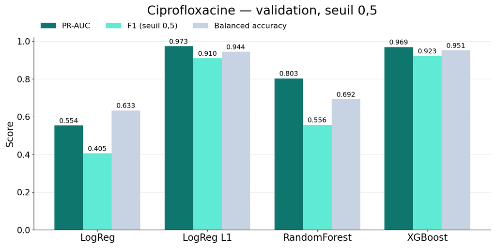

### Lecture

- **LogReg L1** : PR-AUC **0,973** avec seulement **68 variables**.
- **XGBoost** : PR-AUC 0,969 et meilleur F1 (**0,923**).
- **Random Forest** : PR-AUC 0,803 mais **recall 0,385** → rate 6 résistants sur 10.
- **LogReg** : 0,554, sous-ajuste.
- Hasard (prévalence) : **0,167**.

> Deux modèles au coude à coude : XGBoost et une L1 de 68 variables.

## L1 : combien de variables suffisent ?

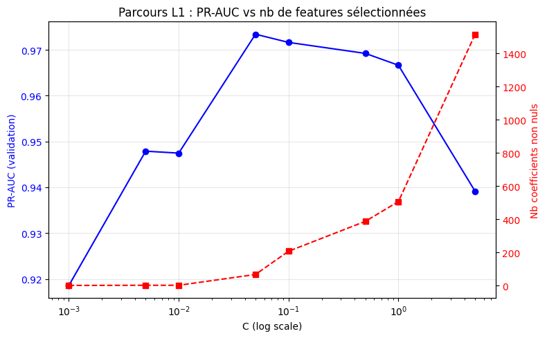

### Le parcours

- `C = 0,001` : **2 variables**, PR-AUC **0,919** — deux mutations suffisent presque.
- **`C = 0,05` : 68 variables, PR-AUC 0,973** ← retenu.
- `C = 5` : **1 515 variables**, PR-AUC **0,939** — ajouter des features dégrade.

> **68 variables sur 20 929** (0,32 %) suffisent ; au-delà, le score baisse.

## Les variables retenues par L1

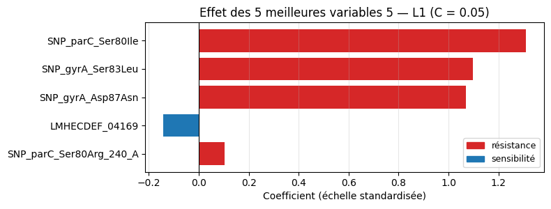

### Lecture biologique

- `SNP_parC_Ser80Ile` **+1,31**.
- `SNP_gyrA_Ser83Leu` **+1,10**.
- `SNP_gyrA_Asp87Asn` **+1,07**.
- Les trois mutations QRDR portent **64 %** de la masse des coefficients.
- 37 coefficients positifs, 31 négatifs ; le reste est ≤ 0,15 en valeur absolue.

> Signal **spécifique** : contrairement à la céfuroxime, les premières variables sont le mécanisme même de la fluoroquinolone.

## Du score à la décision : choisir le seuil

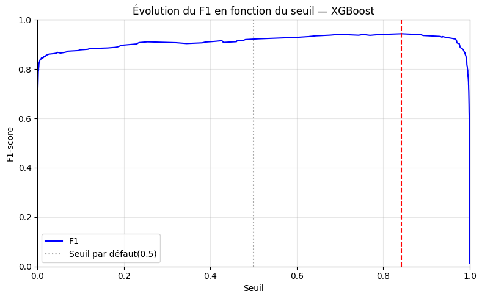

### XGBoost — validation

- Seuil F1 max : **0,842**.
- Plateau large : F1 ≈ **0,92–0,94** entre **0,4 et 0,9**.
- À 0,5, F1 = 0,923 : le gain du seuil optimal est **marginal**.

### Pourquoi ce seuil ?

- Probabilités **polarisées** ; calibration légèrement **optimiste**.
- Seuil choisi et mesuré sur la validation → estimation **optimiste**.
- Appliqué une seule fois au test, sans retouche.

## Calibration des probabilités

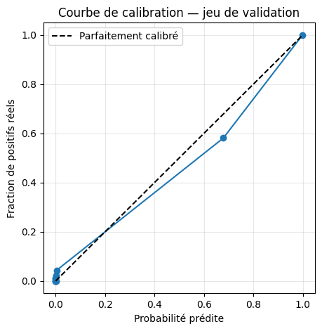

### Lecture

- Courbe proche de la diagonale : calibration **globalement bonne**.
- Entre 0,4 et 0,8, les points sont **sous** la diagonale → modèle légèrement **optimiste**.
- Une probabilité prédite de 0,67 correspond à ≈ 0,58 de positifs réels.

### Ce que cela implique

- Le seuil élevé (0,842) reste cohérent avec des scores polarisés.
- Pour un usage clinique, il faudrait **recalibrer** (Platt / isotonic) avant de donner une probabilité.

## Évaluation finale sur le test

### XGBoost, seuil 0,842 (figé sur la validation)

| Accuracy | Bal. acc | Precision | Recall R | F1 R | ROC-AUC | PR-AUC |
| --- | --- | --- | --- | --- | --- | --- |
| 0,981 | 0,952 | 0,972 | 0,909 | 0,940 | 0,972 | **0,951** |

### Matrice de confusion (929 génomes)

|  | Prédit sensible | Prédit résistant |
| --- | --- | --- |
| **Sensible** | 771 | 4 |
| **Résistant** | 14 | 140 |

### Lecture

- **91 %** des résistants détectés ; **14 résistants manqués**.
- Précision 97 % : **4 faux positifs** seulement.
- PR-AUC **0,951** contre **0,166** au hasard → signal fort, mais 14 erreurs restent.

## Interprétabilité globale : SHAP

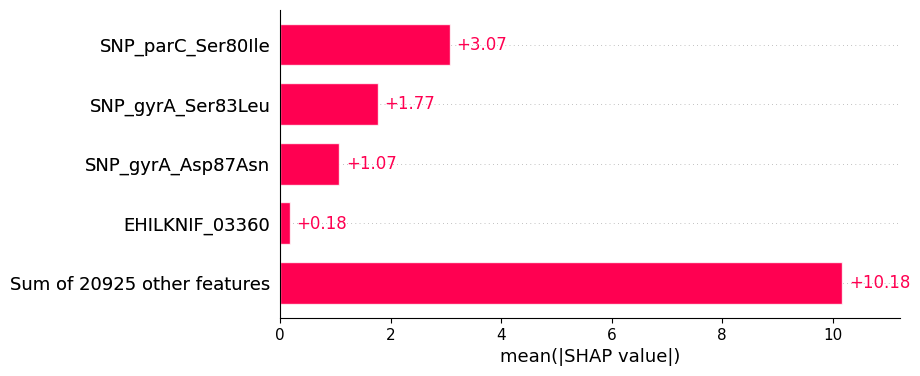

- `parC_Ser80Ile` : **+3,07** de |SHAP| moyen.
- `gyrA_Ser83Leu` : +1,77 ; `gyrA_Asp87Asn` : +1,07.
- Les trois mutations = **36 %** de l’attribution totale.
- Les 20 925 autres features se partagent 10,18 : signal résiduel **diffus**.

> Utile **et** spécifique : le modèle s’appuie d’abord sur le mécanisme connu.

## Faux positif : trois mutations, phénotype sensible

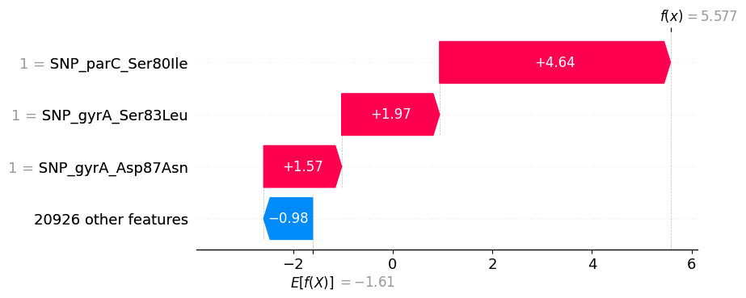

### Prédit R, réellement S

- Score `f(x) = 5,58` → probabilité **0,996** (> seuil 0,842).
- `parC_Ser80Ile` +4,64, `gyrA_Ser83Leu` +1,97, `gyrA_Asp87Asn` +1,57.
- Les **trois mutations canoniques** sont présentes, mais le phénotype est **sensible** : erreur d’annotation, fond génétique ou cas particulier.

> Le modèle suit le mécanisme ; c’est le **phénotype** qui surprend.

## Faux négatif : un mécanisme absent de la matrice

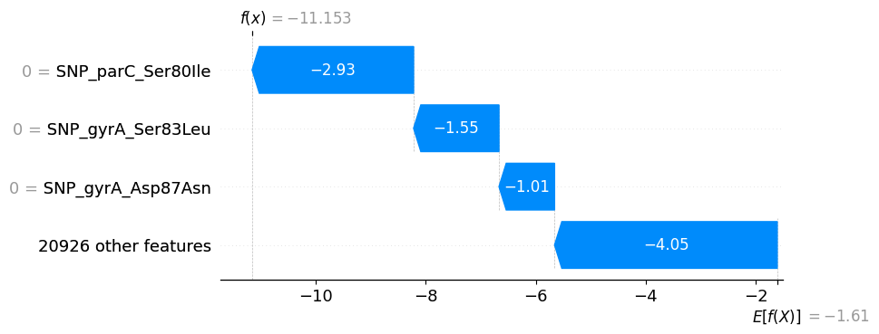

### Prédit S, réellement R

- Score très bas : `f(x) = −11,15` → probabilité ≈ **1,4 × 10⁻⁵**.
- Aucune mutation QRDR : `parC`, `gyrA_Ser83Leu`, `gyrA_Asp87Asn` = 0.
- Les autres features pèsent −4,05 : rien ne signale la résistance.
- Mécanisme probablement **hors représentation** : `qnr`, `aac(6')-Ib-cr`, efflux, porines.

> Les faux négatifs révèlent les **limites de la représentation**.

## Deep learning : MLP sur les 20 929 features

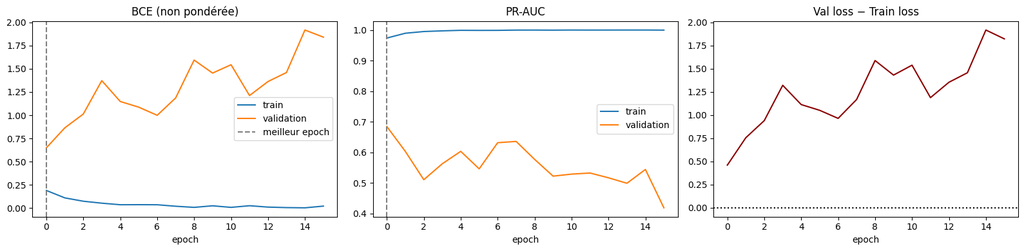

### Architecture

- `20 929 → 512 → 128 → 32 → 1` ; BatchNorm, dropout 0,3 / 0,2.
- AdamW, `pos_weight ≈ 3,18`, early stopping (patience 15).

### Entraînement

- Meilleur epoch : **0** (PR-AUC val **0,685**), arrêt à 15 ; la loss de validation **diverge**.
- Test (seuil 0,776) : PR-AUC **0,730** · F1 **0,701** · recall **0,714**.

## MLP avec sélection de variables (top 50 SHAP)

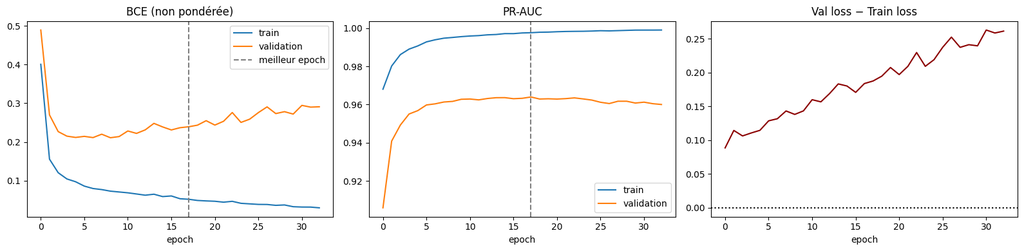

### Protocole

- Top 50 features par **|SHAP| moyen** (1 000 génomes).
- `50 → 64 → 16 → 1`, dropout 0,5.

### Résultats

- Meilleur epoch : **17** (PR-AUC val **0,964**), arrêt à 32.
- Test (seuil 0,960) : PR-AUC **0,954** · F1 **0,943** · bal. acc **0,953**.

### Lecture

- Égalise XGBoost (**0,954 vs 0,951**), mais **après** sélection SHAP par XGBoost.

## Récapitulatif — ciprofloxacine, test

### Trois modèles évalués sur le test, un seuil choisi sur la validation

| Modèle | Seuil | PR-AUC | F1 | Recall R | Bal. acc |
| --- | --- | --- | --- | --- | --- |
| **XGBoost** | 0,842 | 0,951 | 0,940 | 0,909 | 0,952 |
| MLP (toutes features) | 0,776 | 0,730 | 0,701 | 0,714 | 0,825 |
| MLP (top 50) | 0,960 | **0,954** | **0,943** | 0,909 | **0,953** |

*LogReg L1 : PR-AUC 0,973 en validation, non réévaluée sur le test dans le notebook.*

### Ce qu’il faut retenir

- **XGBoost** est la référence ; le MLP top-50 fait jeu égal, à **0,3 point** près.
- Le MLP complet est **22 points** en dessous du PR-AUC.
- Sur 154 résistants, ces écarts ne sont pas tous significatifs : il faut des **intervalles de confiance**.

> Le deep learning n’apporte pas de gain **autonome** sur cette matrice tabulaire.

## Passage à l’échelle : 8 antibiotiques

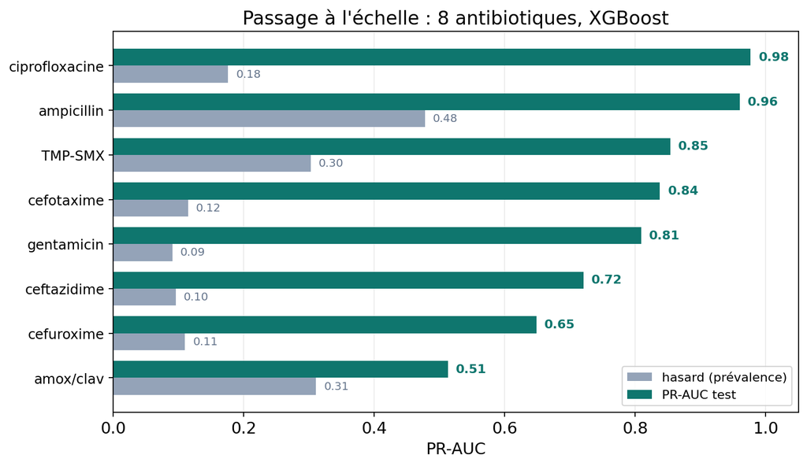

### Le pipeline

- `run_antibiotic_pipeline(atb, data)` — mêmes modèles, même protocole.
- Un artefact `.joblib` par ATB.

### Les résultats (test)

- cipro **0,98** · ampicilline **0,96** · TMP-SMX **0,85**
- cefotaxime **0,84** · gentamicine **0,81** · ceftazidime **0,72**
- cefuroxime **0,65** · amox/clav **0,51**
- Tous au-dessus du hasard, gains **très inégaux**.

## Ce que le classement nous apprend

### La performance suit la biologie de la résistance

- **Facile** : mutations ponctuelles ciblées — fluoroquinolones, ampicilline → **0,95–0,98**.
- **Moyen** : bêta-lactamines à spectre étendu, aminoglycosides → **0,72–0,85**.
- **Difficile** : amoxicilline/acide clavulanique → **0,51**, à peine mieux que le hasard (0,31).

### La prévalence n’explique pas tout

- Amox/clav : **31 %** de résistants, mais un PR-AUC de 0,51.
- Ciprofloxacine : **18 %** de résistants, PR-AUC de **0,95–0,98** selon le pipeline.
- Ce qui change : la **génétique de la résistance** (SNP ciblés vs mécanismes multiples).

### Conséquence

> Choisir l’antibiotique n’est pas un détail technique : c’est **formuler le problème**.

## Limites

- **Tests petits** : 929 / 154 R (cipro) ; 656 / 72 R (céfuroxime) → IC larges.
- **Deux jeux différents** : 20 929 vs 34 744 features, splits dédiés → scores non strictement comparables.
- **Split groupé par lignée**, pas par phylogénie fine.
- **Pas de validation externe** (autre cohorte, autre pays).
- **Seuil choisi et mesuré sur la validation** → estimation optimiste.
- **Calibration explorée, non corrigée** (Platt / isotonic).
- **Deep learning** : une architecture, un seed ; MLP complet = epoch 0.
- **Mécanismes manquants** : 14 faux négatifs cipro sans QRDR → `qnr`, efflux, porines.
- **Co-résistance** : sur la céfuroxime, `parC` / `gyrA` = marqueurs de lignage.
- **Phénotypes hétérogènes** entre études.

## Perspectives

### Consolider la mesure

- Validation croisée groupée à 5 folds, plusieurs seeds, **bootstrap** pour les IC.
- **Validation externe** et seuil figé évalué sur le test.
- **Recalibration** (Platt / isotonic) intégrée à la décision.

### Améliorer le signal

- Modèle **multi-tâches** : partager l’information entre les 48 ATB.
- Features ciblées : **bêta-lactamases, porines, efflux**, plasmides, `qnr`, `aac(6')-Ib-cr`.
- Annotation des clusters inconnus (`EHILKNIF_03360`, `LMHECDEF_04169`…).

### Rendre l’outil utilisable

- Prédiction à partir d’un génome, avec **abstention** hors domaine de validité.
- Restituer la **probabilité calibrée** et les variables contributives, pas seulement R/S.

## Conclusion

### Ce que l’on retient

- **48 ATB → 9 exploitables** en critère strict : la couverture et la prévalence sont des filtres décisifs.
- **Ciprofloxacine**, cas de référence : XGBoost atteint **0,951** de PR-AUC test, contre **0,166** au hasard.
- La **L1** retrouve **68 variables** sur 20 929 ; les trois mutations QRDR portent **64 %** de la masse des coefficients.
- Le **deep learning** complet échoue (**0,730**) ; avec les 50 features choisies par XGBoost, il égale XGBoost (**0,954**), sans gain autonome.
- La performance varie de **0,51 à 0,98** selon l’antibiotique : la cible compte autant que le modèle.

> Le bon modèle n’est pas le plus complexe : c’est celui qui capture un signal biologique réel, généralise sur des lignées non vues et sait dire **ce qu’il ne sait pas**.

## Questions

### Merci de votre attention

- Cas de référence : `notebooks/ciprofloxacine_exploration.ipynb`
- Passage à l’échelle : `notebooks/all_antibiotic.ipynb`
- Pipeline : `src/pipeline.py`
- Rapports : `reports/coverage_by_atb.csv`, `reports/summary_by_atb.csv`
- Présentation générée avec **Quarto + Reveal.js**